# Procesamiento Avanzado de Imágenes Médicas

Ingeniería Biomédica

Ph.D. Pablo Eduardo Caicedo Rodríguez

2026-09-27

# Procesado Avanzado de Imágenes Médicas - PAIM

## Introducción: El Sistema de Comunicación

La adquisición de imágenes por rayos X (RX) y tomografía computarizada (CT) puede modelarse como un **sistema de transferencia de información** donde el haz de fotones actúa como portador, el paciente como canal modulador y el detector como transductor.

La calidad diagnóstica final depende de la integridad de cada eslabón en la cadena de procesamiento.

## 1. Formación del Haz y Geometría

La calidad de la fuente define el límite superior de la resolución espacial y la SNR inicial.

- **Filtración:** Endurecimiento del haz para reducir la dosis en piel y artefactos de baja energía.
- **Geometría:** El tamaño de la mancha focal ($f$) induce una penumbra ($\sigma$):
  $$\text{Penumbra} = f \cdot \frac{d_{p-d}}{d_{s-p}}$$
- **Dispersión:** Controlada mediante colimadores para limitar el volumen irradiado.

A continuación, presento la estructura de las diapositivas en Quarto utilizando un enfoque didáctico simplificado, pero manteniendo el rigor de las relaciones físicas fundamentales.

## 1. El Tubo: Una Máquina de Colisiones

Imagine un acelerador de partículas en miniatura:

- **Cátodo:** Un filamento que se calienta para soltar electrones (como corredores en la línea de salida).
- **Voltaje ($kVp$):** El “empujón” eléctrico. A mayor voltaje, los electrones corren más rápido.
- **Ánodo:** El muro de metal donde los electrones chocan violentamente.

## El Proceso de Generación

```
graph LR
    A[Electrones Libres] --> B{Aceleración kVp}
    B --> C[Choque en el Ánodo]
    C --> D[Rayos X 1%]
    C --> E[Calor 99%]
```

## 2. ¿Cómo se crea el Rayo X?

Ocurren dos fenómenos en el “muro” (ánodo):

1. **El Frenazo (*Bremsstrahlung*):** El electrón frena bruscamente al pasar cerca de un átomo. La energía que pierde al frenar sale como un fotón.
2. **El Choque Directo:** El electrón golpea a otro electrón del átomo y lo expulsa. Al reordenarse, el átomo libera energía muy específica.

## 3. El Material del Ánodo ($Z$)

El **Número Atómico ($Z$)** representa qué tan “denso” es el muro de átomos.

- Si el muro es de **Tungsteno ($Z=74$)**, hay muchos obstáculos y los electrones chocan con más fuerza.
- **Resultado:** Producimos muchos más rayos X que si usáramos un metal ligero.

## 4. La Mezcla de Energías $I(E)$

Los rayos X no son todos iguales; salen en una “mezcla”:

- **Baja Energía:** No atraviesan al paciente, solo dañan la piel.
- **Alta Energía:** Son los útiles para ver los huesos.

**La Filtración:** Colocamos una lámina de metal (Aluminio) para “limpiar” la mezcla y dejar pasar solo los rayos fuertes.

## 5. La Penumbra: El Problema del Tamaño

¿Por qué algunas radiografías se ven borrosas?

- Si el punto de choque en el ánodo es **grande**, las sombras tienen bordes difusos.
- **Matemáticamente:** $P = f \cdot \frac{d_{OD}}{d_{SO}}$
- Para una imagen nítida, necesitamos que el foco ($f$) sea lo más pequeño posible.

## 6. SNR: ¿Por qué la imagen se ve con “grano”?

La **Relación Señal-Ruido (SNR)** es la limpieza de la imagen.

- **Poca radiación:** La imagen se ve granulada (como una foto de noche).
- **Mucha radiación:** La imagen es clara, pero el paciente recibe más dosis.
- **Límite físico:** $SNR \approx \sqrt{N}$ (donde $N$ es el número de fotones).

## Resumen de la Cadena

Para obtener una buena imagen necesitamos:

1. Suficiente fuerza ($kVp$).
2. Un muro denso (alto $Z$).
3. Un filtro que limpie la mezcla ($I(E)$).
4. Un punto de choque pequeño para evitar la **penumbra**.
5. Suficientes fotones para una buena **SNR**.

## 2. Interacción con el Paciente

El paciente actúa como un filtro espacialmente variante definido por $\mu(x, y, z, E)$.

- **Atenuación:** Regida por la ley de Beer-Lambert (para haces monocromáticos):
  $$I = I_0 e^{-\int \mu(l) dl}$$
- **Efecto Compton:** Principal fuente de *scatter*, reduciendo el contraste de la señal primaria.
- **Atenuación Polienergética:** Provoca el *beam hardening*, ya que $\mu$ decrece con el aumento de $E$.

## 1. El Fenómeno de Atenuación

La absorción de rayos X no es un evento binario, sino un proceso estocástico de remoción de fotones del haz primario.

- **Atenuación:** Suma de absorción y dispersión.
- **Variable crítica:** Fluencia de energía que alcanza el detector.

## 2. Formalismo Matemático: Ley de Beer-Lambert

Para un haz monoenergético en un medio homogéneo:

$$I = I_0 e^{-\mu x}$$

En la anatomía humana (heterogénea), el modelo se convierte en una integral de línea:

$$I = I_0 \exp\left( -\int_{L} \mu(s, E) \, ds \right)$$

> **Nota:** En procesamiento de imágenes, aplicamos $\ln(I_0/I)$ para linealizar la proyección.

## 3. Coeficientes de Atenuación ($\mu$)

El coeficiente de atenuación lineal $\mu$ ($cm^{-1}$) depende de la densidad física $\rho$ y la energía $E$.

$$\mu = \rho \cdot \left( \frac{\mu}{\rho} \right)$$

- **Coeficiente másico ($\mu/\rho$):** Independiente del estado físico, disponible en tablas NIST XCOM.
- **Dependencia de Z:** El contraste depende de la relación $\propto Z^3/E^3$.

## 4. Física de la Interacción

A energías diagnósticas (20-150 keV), dominan dos mecanismos:

1. **Efecto Fotoeléctrico:** Absorción total. Define el contraste radiográfico (Hueso vs. Tejido).
2. **Efecto Compton:** Dispersión. Genera ruido y reduce la relación señal-ruido (SNR).

## 5. Factores Críticos: Acumulación y Divergencia

### Factor de Acumulación ($B$)

Corrige la radiación dispersa que llega al detector:
$$I = I_0 \cdot B \cdot e^{-\mu x}$$

### Divergencia (Cuadrado Inverso)

La intensidad decae con la distancia $d$:
$$I \propto \frac{1}{d^2}$$

## 6. Representación en la Imagen Digital

| Etapa | Variable Física |
| --- | --- |
| **Raw (Crudo)** | Exposición / Fluencia (Kerma). |
| **Log-Transformed** | Integral de línea de $\mu$. |
| **Clínica (DICOM)** | Índice de luminancia (No lineal). |

## 7. Simulación: Endurecimiento del Haz (Python)

El “Beam Hardening” ocurre porque los fotones de baja energía se atenúan más rápido, aumentando la energía media del haz.

```python
import numpy as np

# Configuración NumPy 2.0+
E = np.linspace(10, 100, 500)
I0 = np.maximum(74 * (100 - E), 0)

# Atenuación en 2cm de Hueso
mu_bone = 20000 * (E**-3) + 0.18
I_trans = I0 * np.exp(-mu_bone * 2.0)

# Cálculo de Energía Media (Endurecimiento)
e_ini = np.trapezoid(I0 * E, E) / np.trapezoid(I0, E)
e_fin = np.trapezoid(I_trans * E, E) / np.trapezoid(I_trans, E)

print(f"E_media inicial: {e_ini:.2f} keV")
print(f"E_media final: {e_fin:.2f} keV")
```

[output not shown]

## Flujo de la Cadena Física-Digital

```
graph LR
    A[Generación Haz] --> B[Interacción Paciente]
    B --> C[Detección Fotónica]
    C --> D[Digitalización ADC]
    D --> E[Procesamiento/Recon]
    E --> F[Visualización]
```

## 3. Respuesta del Detector

El detector es el componente más crítico en la degradación de la resolución espacial y el ruido.

- **MTF (Modulation Transfer Function):** Define la respuesta en frecuencia espacial.
- **DQE (Detective Quantum Efficiency):**
  $$DQE(f) = \frac{SNR_{out}^2(f)}{SNR_{in}^2(f)}$$
- **Factores Limitantes:** *Lag* de fósforo, ruido electrónico y saturación del rango dinámico.

## 4. Digitalización y Cuantización

Transformación de la señal analógica continua en un dominio discreto.

- **ADC:** Conversión de corriente/voltaje a niveles digitales.
- **Bit-depth:** Define la resolución en contraste. Generalmente 12-16 bits.
- **Ruido de Cuantización:** Si el paso de cuantización $q$ es grande:
  $$\sigma_q^2 = \frac{q^2}{12}$$

## 5. Calibración y Datos Crudos

Antes de la reconstrucción, los datos deben normalizarse.

1. **Dark Current:** Corrección de la señal térmica sin exposición.
2. **Flat-field:** Compensación de la sensibilidad no uniforme entre píxeles.
3. **Beam Hardening Correction:** Modelado matemático para linealizar el sinograma respecto al espesor del material.

## 6. Reconstrucción de la Imagen

En CT, se resuelve el problema inverso de la Transformada de Radon.

- **FBP (Filtered Back Projection):** Implementación eficiente en frecuencia:
  $$\hat{f}(x,y) = \int_0^\pi [p(\cdot, \theta) * k] d\theta$$
- **Iterativa (MBIR):** Optimización de una función de costo estocástica. Es superior en presencia de ruido y dosis bajas, pero computacionalmente costosa.

## 7. Posproceso y Visualización

Mapeo de la profundidad de bits del detector a la capacidad del sistema visual humano.

- **Escala Hounsfield:**
  $$HU = 1000 \times \frac{\mu_x - \mu_{w}}{\mu_{w} - \mu_{a}}$$
- **Windowing:** Selección de *Window Level* (WL) y *Window Width* (WW) para resaltar estructuras específicas (hueso vs. parénquima).

## 8. QA y Validación

Cierre del lazo de control de calidad.

- **Phantoms:** Evaluación de linealidad, resolución de bajo contraste y espesor de corte.
- **Métricas de Dosis:** CTDIvol y DLP para cumplimiento del principio ALARA.
- **Estabilidad Temporal:** Seguimiento de la deriva del detector y calibración del tubo.

## Conclusión

La optimización de la calidad diagnóstica no puede realizarse de forma aislada. La integración de **IA Confiable** y **IA Causal** en las etapas 5 (calibración) y 6 (reconstrucción) es el paradigma actual para minimizar la dosis sin comprometer la interpretabilidad clínica.

## Codigo

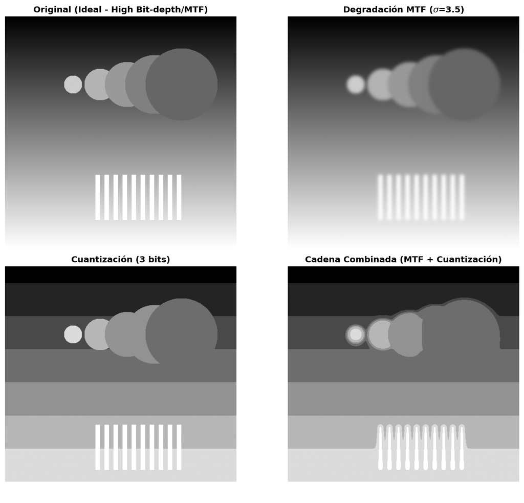

```python
import numpy as np
import matplotlib.pyplot as plt
from scipy.ndimage import gaussian_filter
from skimage.exposure import rescale_intensity


def generate_phantom(size=512):
    """Genera un fantoma sintético con gradientes y estructuras de alta frecuencia."""
    image = np.zeros((size, size))
    # Gradiente para ver cuantización
    xx, yy = np.mgrid[0:size, 0:size]
    image = xx / size
    # Estructuras circulares (baja y alta frecuencia)
    for i in range(5):
        r = 20 + i * 15
        mask = (xx - 150) ** 2 + (yy - 150 - i * 60) ** 2 < r**2
        image[mask] = 0.8 - (i * 0.1)
    # Barras de resolución (alta frecuencia)
    for i in range(10):
        image[350:450, 200 + i * 20 : 210 + i * 20] = 1.0
    return image


def simulate_mtf(image, sigma):
    """
    Simula la degradación por MTF mediante la convolución con una PSF Gaussiana.
    A mayor sigma, menor frecuencia de corte en la MTF.
    """
    return gaussian_filter(image, sigma=sigma)


def simulate_quantization(image, bit_depth):
    """
    Simula el proceso de cuantización del ADC.
    """
    levels = 2**bit_depth - 1
    quantized = np.round(image * levels) / levels
    return quantized


# --- Parámetros de simulación ---
sigma_psf = 3.5  # Representa una MTF deficiente
bits_low = 3  # Cuantización extrema para visualización

# Procesamiento
original = generate_phantom()
blurred = simulate_mtf(original, sigma_psf)
quantized = simulate_quantization(original, bits_low)
combined = simulate_quantization(blurred, bits_low)

# Visualización
fig, axes = plt.subplots(2, 2, figsize=(12, 10))
titles = [
    "Original (Ideal - High Bit-depth/MTF)",
    f"Degradación MTF ($\sigma$={sigma_psf})",
    f"Cuantización ({bits_low} bits)",
    "Cadena Combinada (MTF + Cuantización)",
]
images = [original, blurred, quantized, combined]

for ax, img, title in zip(axes.ravel(), images, titles):
    im = ax.imshow(img, cmap="gray", vmin=0, vmax=1)
    ax.set_title(title, fontsize=12, fontweight="bold")
    ax.axis("off")

plt.tight_layout()
plt.show()
```